# FE621HW1Jerry

## Part 1

### 1. Write a function (program) to connect to sources and download data

### Yahoo/Google Finance API / URL not working. How to fix it?

Here is the stack overflow page.

https://stackoverflow.com/questions/44112403/yahoo-finance-api-url-not-working-python-fix-for-pandas-datareader

Quora page:

https://www.quora.com/Using-Python-whats-the-best-way-to-get-stock-data

### Here, I only implement the naive api for illustration. In problem 2, I wrote another function "get_option_yahoo" to fetch the data.

### Yahoo finance

```
[*********************100%***********************]  1 of 1 downloaded
```

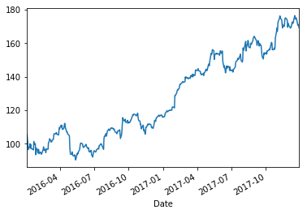

```python
import matplotlib.pyplot as plt
import fix_yahoo_finance as yf
data = yf.download('AAPL','2016-01-01','2018-01-01')
data.Close.plot()
plt.show()
```

```python
from pandas_datareader import data as pdr

import fix_yahoo_finance as yf
yf.pdr_override() # <== that's all it takes :-)

# download dataframe
data = pdr.get_data_yahoo("SPY", start="2017-01-01", end="2017-04-30")

# download Panel
data = pdr.get_data_yahoo(["SPY", "VIX","AMZN"], start="2017-01-01", end="2017-04-30")
```

```
[*********************100%***********************]  1 of 1 downloaded
[*********************100%***********************]  3 of 3 downloaded
```

```python
data
```

| Date | Open AMZN | Open VIX | Open SPY | High AMZN | High VIX | High SPY | Low AMZN | Low VIX | Low SPY | Close AMZN | Close VIX | Close SPY | Adj Close AMZN | Adj Close VIX | Adj Close SPY | Volume AMZN | Volume VIX | Volume SPY |
| --- | --- | --- | --- | --- | --- | --- | --- | --- | --- | --- | --- | --- | --- | --- | --- | --- | --- | --- |
| 2017-01-03 | 757.919983 | 4952.379883 | 225.039993 | 758.760010 | 5238.100098 | 225.830002 | 747.700012 | 4761.899902 | 223.880005 | 753.669983 | 5238.100098 | 225.240005 | 753.669983 | 5238.100098 | 219.079453 | 3521100 | 217416.0 | 91366500 |
| 2017-01-04 | 758.390015 | 5142.859863 | 225.619995 | 759.679993 | 5333.330078 | 226.750000 | 754.200012 | 5142.859863 | 225.610001 | 757.179993 | 5238.100098 | 226.580002 | 757.179993 | 5238.100098 | 220.382797 | 2510500 | 54528.0 | 78744400 |
| 2017-01-05 | 761.549988 | 5142.859863 | 226.270004 | 782.400024 | 5238.100098 | 226.580002 | 760.260010 | 5047.620117 | 225.479996 | 780.450012 | 5238.100098 | 226.399994 | 780.450012 | 5238.100098 | 220.207718 | 5830100 | 38974.0 | 78379000 |
| 2017-01-06 | 782.359985 | 5142.859863 | 226.529999 | 799.440002 | 5238.100098 | 227.750000 | 778.479980 | 5047.620117 | 225.899994 | 795.989990 | 5047.620117 | 227.210007 | 795.989990 | 5047.620117 | 220.995575 | 5986200 | 102008.0 | 71559900 |
| 2017-01-09 | 798.000000 | 4952.379883 | 226.910004 | 801.770020 | 5142.859863 | 227.070007 | 791.770020 | 4952.379883 | 226.419998 | 796.919983 | 5047.620117 | 226.460007 | 796.919983 | 5047.620117 | 220.266083 | 3440100 | 129879.0 | 46265300 |
| 2017-01-10 | 796.599976 | 5047.620117 | 226.479996 | 798.000000 | 5142.859863 | 227.449997 | 789.539978 | 4952.379883 | 226.009995 | 795.900024 | 4952.379883 | 226.460007 | 795.900024 | 4952.379883 | 220.266083 | 2558400 | 41354.0 | 63771900 |
| 2017-01-11 | 793.659973 | 5047.620117 | 226.360001 | 799.500000 | 5428.569824 | 227.100006 | 789.510010 | 5047.620117 | 225.589996 | 799.020020 | 5333.330078 | 227.100006 | 799.020020 | 5333.330078 | 220.888580 | 2992800 | 163764.0 | 74650000 |
| 2017-01-12 | 800.309998 | 5238.100098 | 226.500000 | 814.130005 | 5238.100098 | 226.750000 | 799.500000 | 5142.859863 | 224.960007 | 813.640015 | 5238.100098 | 226.529999 | 813.640015 | 5238.100098 | 220.334152 | 4873900 | 86625.0 | 72113200 |
| 2017-01-13 | 814.320007 | 5238.100098 | 226.729996 | 821.650024 | 5333.330078 | 227.399994 | 811.400024 | 5047.620117 | 226.690002 | 817.140015 | 5047.620117 | 227.050003 | 817.140015 | 5047.620117 | 220.839935 | 3791900 | 58165.0 | 62717900 |
| 2017-01-17 | 815.700012 | 5047.620117 | 226.309998 | 816.000000 | 5142.859863 | 226.779999 | 803.440002 | 5047.620117 | 225.800003 | 809.719971 | 5142.859863 | 226.250000 | 809.719971 | 5142.859863 | 220.061829 | 3659400 | 183776.0 | 59261200 |
| 2017-01-18 | 809.500000 | 5142.859863 | 226.539993 | 811.729980 | 5619.049805 | 226.800003 | 804.270020 | 5142.859863 | 225.899994 | 807.479980 | 5619.049805 | 226.750000 | 807.479980 | 5619.049805 | 220.548157 | 2354200 | 1325070.0 | 54793300 |
| 2017-01-19 | 810.000000 | 5619.049805 | 226.839996 | 813.510010 | 5809.520020 | 227.000000 | 807.320007 | 5428.569824 | 225.410004 | 809.039978 | 5523.810059 | 225.910004 | 809.039978 | 5523.810059 | 219.731110 | 2540800 | 338152.0 | 66608800 |
| 2017-01-20 | 815.280029 | 5523.810059 | 226.699997 | 816.020020 | 5523.810059 | 227.309998 | 806.260010 | 5428.569824 | 225.970001 | 808.330017 | 5523.810059 | 226.740005 | 808.330017 | 5523.810059 | 220.538422 | 3376200 | 163275.0 | 129168600 |
| 2017-01-23 | 806.799988 | 5428.569824 | 226.740005 | 818.500000 | 5619.049805 | 226.809998 | 805.080017 | 5238.100098 | 225.270004 | 817.880005 | 5523.810059 | 226.149994 | 817.880005 | 5523.810059 | 219.964539 | 2797500 | 186290.0 | 75061600 |
| 2017-01-24 | 822.000000 | 5523.810059 | 226.399994 | 823.989990 | 5714.290039 | 228.080002 | 814.500000 | 5523.810059 | 226.270004 | 822.440002 | 5714.290039 | 227.600006 | 822.440002 | 5714.290039 | 221.374893 | 2971700 | 160440.0 | 95555300 |
| 2017-01-25 | 825.789978 | 5714.290039 | 228.699997 | 837.419983 | 6095.240234 | 229.570007 | 825.289978 | 5714.290039 | 228.509995 | 836.520020 | 6095.240234 | 229.570007 | 836.520020 | 6095.240234 | 223.291016 | 3922600 | 645625.0 | 84437700 |
| 2017-01-26 | 835.530029 | 6095.240234 | 229.399994 | 843.840027 | 6095.240234 | 229.710007 | 833.000000 | 6095.240234 | 229.009995 | 839.150024 | 6095.240234 | 229.330002 | 839.150024 | 6095.240234 | 223.057571 | 3586300 | 0.0 | 59970700 |
| 2017-01-27 | 839.000000 | 6095.240234 | 229.419998 | 839.700012 | 6095.240234 | 229.589996 | 829.440002 | 6095.240234 | 228.759995 | 835.770020 | 6095.240234 | 228.970001 | 835.770020 | 6095.240234 | 222.707413 | 2998700 | 0.0 | 59711100 |
| 2017-01-30 | 833.000000 | 6095.240234 | 228.169998 | 833.500000 | 6095.240234 | 228.199997 | 816.380005 | 6095.240234 | 226.410004 | 830.380005 | 6095.240234 | 227.550003 | 830.380005 | 6095.240234 | 221.326263 | 3747300 | 0.0 | 79737300 |
| 2017-01-31 | 823.750000 | 6095.240234 | 226.979996 | 826.989990 | 6095.240234 | 227.600006 | 819.559998 | 6095.240234 | 226.320007 | 823.479980 | 6095.240234 | 227.529999 | 823.479980 | 6095.240234 | 221.306808 | 3137200 | 0.0 | 75880800 |
| 2017-02-01 | 829.210022 | 6095.240234 | 227.529999 | 833.780029 | 6095.240234 | 228.589996 | 824.940002 | 6095.240234 | 226.940002 | 832.349976 | 6095.240234 | 227.619995 | 832.349976 | 6095.240234 | 221.394333 | 3850200 | 0.0 | 79117700 |
| 2017-02-02 | 836.590027 | 6095.240234 | 227.619995 | 842.489990 | 6095.240234 | 228.100006 | 828.260010 | 6095.240234 | 226.820007 | 839.950012 | 6095.240234 | 227.770004 | 839.950012 | 6095.240234 | 221.540253 | 7350500 | 0.0 | 69657600 |
| 2017-02-03 | 806.719971 | 5904.759766 | 228.820007 | 818.299988 | 6000.000000 | 229.550003 | 804.000000 | 5714.290039 | 228.460007 | 810.200012 | 5714.290039 | 229.339996 | 810.200012 | 5714.290039 | 223.067307 | 10868800 | 240398.0 | 80563200 |
| 2017-02-06 | 809.799988 | 5619.049805 | 228.869995 | 810.719971 | 6000.000000 | 229.330002 | 803.000000 | 5523.810059 | 228.539993 | 807.640015 | 6000.000000 | 228.929993 | 807.640015 | 6000.000000 | 222.668488 | 3897300 | 378240.0 | 57790100 |
| 2017-02-07 | 809.309998 | 5904.759766 | 229.380005 | 816.159973 | 5904.759766 | 229.660004 | 807.500000 | 5714.290039 | 228.720001 | 812.500000 | 5809.520020 | 228.940002 | 812.500000 | 5809.520020 | 222.678253 | 3466100 | 310828.0 | 57931200 |
| 2017-02-08 | 812.690002 | 5714.290039 | 228.940002 | 821.479980 | 5809.520020 | 229.389999 | 812.500000 | 5619.049805 | 228.309998 | 819.710022 | 5619.049805 | 229.240005 | 819.710022 | 5619.049805 | 222.970047 | 2858000 | 421583.0 | 51566200 |
| 2017-02-09 | 821.599976 | 5619.049805 | 229.240005 | 825.000000 | 5714.290039 | 230.949997 | 819.710022 | 5619.049805 | 229.240005 | 821.359985 | 5714.290039 | 230.600006 | 821.359985 | 5714.290039 | 224.292847 | 2484900 | 48111.0 | 65955200 |
| 2017-02-10 | 823.820007 | 5619.049805 | 231.000000 | 828.000000 | 5714.290039 | 231.770004 | 822.849976 | 5523.810059 | 230.619995 | 827.460022 | 5619.049805 | 231.509995 | 827.460022 | 5619.049805 | 225.177948 | 2429600 | 156450.0 | 66015900 |
| 2017-02-13 | 831.619995 | 5619.049805 | 232.080002 | 843.000000 | 5809.520020 | 233.070007 | 828.549988 | 5619.049805 | 232.050003 | 836.530029 | 5809.520020 | 232.770004 | 836.530029 | 5809.520020 | 226.403488 | 4172600 | 178710.0 | 55182100 |
| 2017-02-14 | 837.000000 | 5809.520020 | 232.559998 | 838.309998 | 5809.520020 | 233.710007 | 831.450012 | 5523.810059 | 232.160004 | 836.390015 | 5523.810059 | 233.699997 | 836.390015 | 5523.810059 | 227.308044 | 2787900 | 204041.0 | 67794500 |
| ... | ... | ... | ... | ... | ... | ... | ... | ... | ... | ... | ... | ... | ... | ... | ... | ... | ... | ... |
| 2017-03-17 | 853.489990 | 5904.759766 | 237.750000 | 853.830017 | 6095.240234 | 237.970001 | 850.640015 | 5904.759766 | 237.029999 | 852.309998 | 5904.759766 | 237.029999 | 852.309998 | 5904.759766 | 231.549957 | 3384400 | 905276.0 | 89002100 |
| 2017-03-20 | 851.510010 | 6000.000000 | 237.029999 | 857.799988 | 6380.950195 | 237.360001 | 851.010010 | 6000.000000 | 236.320007 | 856.969971 | 6380.950195 | 236.770004 | 856.969971 | 6380.950195 | 231.295959 | 2282700 | 1664848.0 | 52537000 |
| 2017-03-21 | 858.840027 | 6380.950195 | 237.470001 | 862.799988 | 6380.950195 | 237.610001 | 841.309998 | 6190.479980 | 233.580002 | 843.200012 | 6285.709961 | 233.729996 | 843.200012 | 6285.709961 | 228.326233 | 4382900 | 608811.0 | 131809300 |
| 2017-03-22 | 840.429993 | 6190.479980 | 233.770004 | 849.369995 | 6285.709961 | 234.610001 | 839.049988 | 6095.240234 | 233.050003 | 848.059998 | 6190.479980 | 234.279999 | 848.059998 | 6190.479980 | 228.863525 | 2658700 | 565467.0 | 97569200 |
| 2017-03-23 | 848.200012 | 6190.479980 | 234.279999 | 850.890015 | 6190.479980 | 235.339996 | 844.799988 | 6000.000000 | 233.600006 | 847.380005 | 6095.240234 | 234.029999 | 847.380005 | 6095.240234 | 228.619308 | 1953000 | 496251.0 | 100410300 |
| 2017-03-24 | 851.679993 | 6095.240234 | 234.380005 | 851.799988 | 6285.709961 | 235.039993 | 843.530029 | 6095.240234 | 232.960007 | 845.609985 | 6190.479980 | 233.860001 | 845.609985 | 6190.479980 | 228.453262 | 2138300 | 345555.0 | 112504900 |
| 2017-03-27 | 838.070007 | 6190.479980 | 231.929993 | 850.299988 | 6380.950195 | 233.919998 | 833.500000 | 6095.240234 | 231.610001 | 846.820007 | 6190.479980 | 233.619995 | 846.820007 | 6190.479980 | 228.218796 | 2755800 | 669128.0 | 87454500 |
| 2017-03-28 | 851.750000 | 6190.479980 | 233.270004 | 858.460022 | 6380.950195 | 235.809998 | 850.099976 | 6095.240234 | 233.139999 | 856.000000 | 6285.709961 | 235.320007 | 856.000000 | 6285.709961 | 229.879501 | 3041600 | 626258.0 | 93483900 |
| 2017-03-29 | 859.049988 | 6285.709961 | 234.990005 | 876.440002 | 6380.950195 | 235.809998 | 859.020020 | 6190.479980 | 234.729996 | 874.320007 | 6285.709961 | 235.539993 | 874.320007 | 6285.709961 | 230.094391 | 4485800 | 386680.0 | 61950400 |
| 2017-03-30 | 874.950012 | 6285.709961 | 235.470001 | 877.059998 | 6380.950195 | 236.520004 | 871.659973 | 6095.240234 | 235.270004 | 876.340027 | 6285.709961 | 236.289993 | 876.340027 | 6285.709961 | 230.827057 | 2762700 | 267100.0 | 56737900 |
| 2017-03-31 | 877.000000 | 6190.479980 | 235.899994 | 890.349976 | 6190.479980 | 236.509995 | 876.650024 | 6000.000000 | 235.679993 | 886.539978 | 6000.000000 | 235.740005 | 886.539978 | 6000.000000 | 230.289780 | 3957600 | 248471.0 | 73733100 |
| 2017-04-03 | 888.000000 | 6000.000000 | 235.800003 | 893.489990 | 6000.000000 | 236.029999 | 885.419983 | 5809.520020 | 233.910004 | 891.510010 | 5904.759766 | 235.330002 | 891.510010 | 5904.759766 | 229.889267 | 3422300 | 251259.0 | 85546500 |
| 2017-04-04 | 891.500000 | 5809.520020 | 235.000000 | 908.539978 | 5904.759766 | 235.580002 | 890.280029 | 5714.290039 | 234.559998 | 906.830017 | 5714.290039 | 235.479996 | 906.830017 | 5714.290039 | 230.035797 | 4984700 | 367695.0 | 56466200 |
| 2017-04-05 | 910.820007 | 5809.520020 | 236.259995 | 923.719971 | 5904.759766 | 237.389999 | 905.619995 | 5809.520020 | 234.539993 | 909.280029 | 5809.520020 | 234.779999 | 909.280029 | 5809.520020 | 229.351990 | 7508400 | 260401.0 | 108800600 |
| 2017-04-06 | 913.799988 | 5809.520020 | 234.940002 | 917.190002 | 5809.520020 | 236.039993 | 894.489990 | 5809.520020 | 234.429993 | 898.280029 | 5809.520020 | 235.440002 | 898.280029 | 5809.520020 | 229.996735 | 6344100 | 0.0 | 69135800 |
| 2017-04-07 | 899.650024 | 5809.520020 | 235.149994 | 900.090027 | 5809.520020 | 236.000000 | 889.309998 | 5714.290039 | 234.639999 | 894.880005 | 5714.290039 | 235.199997 | 894.880005 | 5714.290039 | 229.762268 | 3710900 | 281820.0 | 74412300 |
| 2017-04-10 | 899.630005 | 5714.290039 | 235.360001 | 908.510010 | 5904.759766 | 236.259995 | 899.000000 | 5714.290039 | 234.729996 | 907.039978 | 5904.759766 | 235.339996 | 907.039978 | 5904.759766 | 229.899033 | 3184300 | 443246.0 | 67615300 |
| 2017-04-11 | 907.039978 | 5904.759766 | 234.899994 | 911.239990 | 5904.759766 | 235.179993 | 897.500000 | 5714.290039 | 233.339996 | 902.359985 | 5714.290039 | 235.059998 | 902.359985 | 5714.290039 | 229.625504 | 3012700 | 320278.0 | 88045300 |
| 2017-04-12 | 903.090027 | 5714.290039 | 234.740005 | 904.090027 | 5809.520020 | 234.960007 | 895.250000 | 5714.290039 | 233.770004 | 896.229980 | 5714.290039 | 234.029999 | 896.229980 | 5714.290039 | 228.619308 | 2456100 | 322560.0 | 81864400 |
| 2017-04-13 | 891.450012 | 5619.049805 | 233.639999 | 894.969971 | 5714.290039 | 234.490005 | 884.489990 | 5523.810059 | 232.509995 | 884.669983 | 5523.810059 | 232.509995 | 884.669983 | 5523.810059 | 227.134460 | 3174600 | 548530.0 | 92880400 |
| 2017-04-17 | 887.500000 | 5428.569824 | 233.110001 | 902.380005 | 5523.810059 | 234.570007 | 887.500000 | 5333.330078 | 232.880005 | 901.989990 | 5333.330078 | 234.570007 | 901.989990 | 5333.330078 | 229.146835 | 2854700 | 551669.0 | 68405400 |
| 2017-04-18 | 900.989990 | 5428.569824 | 233.720001 | 909.609985 | 5619.049805 | 234.490005 | 900.780029 | 5333.330078 | 233.080002 | 903.780029 | 5619.049805 | 233.869995 | 903.780029 | 5619.049805 | 228.462982 | 2999200 | 593553.0 | 83225800 |
| 2017-04-19 | 907.840027 | 5619.049805 | 234.520004 | 910.500000 | 5619.049805 | 234.949997 | 897.369995 | 5428.569824 | 233.179993 | 899.200012 | 5428.569824 | 233.440002 | 899.200012 | 5428.569824 | 228.042953 | 2870200 | 299250.0 | 68699900 |
| 2017-04-20 | 899.700012 | 5523.810059 | 234.149994 | 905.320007 | 5523.810059 | 235.850006 | 896.289978 | 5428.569824 | 233.779999 | 902.059998 | 5428.569824 | 235.339996 | 902.059998 | 5428.569824 | 229.899033 | 2814400 | 669107.0 | 92572200 |
| 2017-04-21 | 902.669983 | 5523.810059 | 235.250000 | 903.650024 | 5809.520020 | 235.309998 | 896.770020 | 5523.810059 | 234.130005 | 898.530029 | 5714.290039 | 234.589996 | 898.530029 | 5714.290039 | 229.166351 | 2420500 | 1170014.0 | 110389800 |
| 2017-04-24 | 908.679993 | 5714.290039 | 237.179993 | 909.989990 | 6095.240234 | 237.410004 | 903.820007 | 5619.049805 | 234.559998 | 907.409973 | 5904.759766 | 237.169998 | 907.409973 | 5904.759766 | 231.686722 | 3122900 | 1272714.0 | 119209900 |
| 2017-04-25 | 907.039978 | 5904.759766 | 237.910004 | 909.479980 | 6095.240234 | 238.949997 | 903.000000 | 5809.520020 | 237.809998 | 907.619995 | 5904.759766 | 238.550003 | 907.619995 | 5904.759766 | 233.034821 | 3380600 | 788467.0 | 76698300 |
| 2017-04-26 | 910.299988 | 5904.759766 | 238.509995 | 915.750000 | 6095.240234 | 239.529999 | 907.559998 | 5809.520020 | 238.350006 | 909.289978 | 6000.000000 | 238.399994 | 909.289978 | 6000.000000 | 232.888275 | 2608900 | 1659467.0 | 84702500 |
| 2017-04-27 | 914.390015 | 5904.759766 | 238.770004 | 921.859985 | 6095.240234 | 238.949997 | 912.109985 | 5904.759766 | 237.979996 | 918.380005 | 6095.240234 | 238.600006 | 918.380005 | 6095.240234 | 233.083664 | 5305500 | 777600.0 | 57410300 |
| 2017-04-28 | 948.830017 | 6000.000000 | 238.899994 | 949.590027 | 6000.000000 | 238.929993 | 924.330017 | 5904.759766 | 237.929993 | 924.989990 | 6000.000000 | 238.080002 | 924.989990 | 6000.000000 | 232.575684 | 7335800 | 410173.0 | 53247400 |

81 rows × 18 columns

### Quandl api

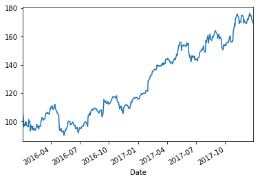

```python
import quandl
quandl.api_config.api_key="UPvqTbKx9vob_1xzMsei"
data = quandl.get("WIKI/AAPL", start_date="2016-01-01", end_date="2018-01-01")
data.Close.plot()
plt.show()
```

```python
data.head()
```

| Date | Open | High | Low | Close | Volume | Ex-Dividend | Split Ratio | Adj. Open | Adj. High | Adj. Low | Adj. Close | Adj. Volume |
| --- | --- | --- | --- | --- | --- | --- | --- | --- | --- | --- | --- | --- |
| 2016-01-04 | 102.61 | 105.368 | 102.00 | 105.35 | 67649387.0 | 0.0 | 1.0 | 99.136516 | 101.801154 | 98.547165 | 101.783763 | 67649387.0 |
| 2016-01-05 | 105.75 | 105.850 | 102.41 | 102.71 | 55790992.0 | 0.0 | 1.0 | 102.170223 | 102.266838 | 98.943286 | 99.233131 | 55790992.0 |
| 2016-01-06 | 100.56 | 102.370 | 99.87 | 100.70 | 68457388.0 | 0.0 | 1.0 | 97.155911 | 98.904640 | 96.489269 | 97.291172 | 68457388.0 |
| 2016-01-07 | 98.68 | 100.130 | 96.43 | 96.45 | 81094428.0 | 0.0 | 1.0 | 95.339552 | 96.740467 | 93.165717 | 93.185040 | 81094428.0 |
| 2016-01-08 | 98.55 | 99.110 | 96.76 | 96.96 | 70798016.0 | 0.0 | 1.0 | 95.213952 | 95.754996 | 93.484546 | 93.677776 | 70798016.0 |

### Bonus Question: Create a program that is capable of downloading multiple assets combine them with the associated time column and save the data into a csv or excel file.

```python
import pandas as pd
def fetch_quandl_data(symbols,start_date,end_date,price_type):
    df = pd.DataFrame()
    for symbol in symbols:

        quandldata = quandl.get("WIKI/{}".format(symbol),start_date=start_date,end_date=end_date)
        quandldata = quandldata[price_type]
        df = pd.concat([df,quandldata],axis=1)
    df.columns = symbols
    df.price_type = price_type
    return df
```

```python
start_date = '2016-01-01'
end_date = '2017-05-22'
```

```python
df = fetch_quandl_data(['AAPL',"AMZN"],start_date,end_date,"Adj. Close")
```

```python
df.head()
```

| Date | AAPL | AMZN |
| --- | --- | --- |
| 2016-01-04 | 101.783763 | 636.99 |
| 2016-01-05 | 99.233131 | 633.79 |
| 2016-01-06 | 97.291172 | 632.65 |
| 2016-01-07 | 93.185040 | 607.94 |
| 2016-01-08 | 93.677776 | 607.05 |

```python
df.to_csv("bonus.csv")
```

### 2. With the function created in problem 1. download data on both options and equity for the following symbols:

- AMZN
- SPY
- VIX

### Equities

```python
day1 = "2017-06-05"
day2 = "2017-06-06"
```

```python
equities_df = pdr.get_data_yahoo(["SPY", "VIX","AMZN"], start=day1, end=day2)
```

```
[*********************100%***********************]  3 of 3 downloaded
```

```python
equities_df
```

| Date | Open AMZN | Open VIX | Open SPY | High AMZN | High VIX | High SPY | Low AMZN | Low VIX | Low SPY | Close AMZN | Close VIX | Close SPY | Adj Close AMZN | Adj Close VIX | Adj Close SPY | Volume AMZN | Volume VIX | Volume SPY |
| --- | --- | --- | --- | --- | --- | --- | --- | --- | --- | --- | --- | --- | --- | --- | --- | --- | --- | --- |
| 2017-06-05 | 1007.22998 | 6476.189941 | 243.970001 | 1013.210022 | 6666.669922 | 244.300003 | 1003.51001 | 6380.950195 | 243.759995 | 1011.340027 | 6380.950195 | 243.990005 | 1011.340027 | 6380.950195 | 238.349060 | 2719900 | 428190 | 44698800 |
| 2017-06-06 | 1012.00000 | 6380.950195 | 243.339996 | 1016.500000 | 6761.899902 | 243.979996 | 1001.25000 | 6380.950195 | 243.119995 | 1003.000000 | 6666.669922 | 243.210007 | 1003.000000 | 6666.669922 | 237.587067 | 3346400 | 1173487 | 50375400 |

### Options and its underlying quote

```python
import datetime
date1 = datetime.datetime(2018,6,17)
date2 = datetime.datetime(2018,6,18)
```

```python
date1_unix = int((date1 - datetime.datetime(1970,1,1)).total_seconds())
```

```python
t_expired = datetime.datetime(2018,9,21)
```

```python
three_months_unix = int((t_expired- datetime.datetime(1970,1,1)).total_seconds())
```

```python
import urllib
import json
from pandas.io.json import json_normalize
def get_option_yahoo(symbol):
    unix_time = three_months_unix # GMT: 2018,9,21 Friday 12 AM
    request = urllib.request.Request("https://query2.finance.yahoo.com/v7/finance/options/{}?date={}".format(symbol,unix_time))
    response = urllib.request.urlopen(request)
    option_data = response.read()
#     print(option_data["optionChain"]["result"])
    data = json.loads(option_data.decode("utf-8"))
    calls_data = data["optionChain"]["result"][0]["options"][0]["calls"][:]
    puts_data = data["optionChain"]["result"][0]["options"][0]["puts"][:]
    calls_df = pd.DataFrame(calls_data)
    puts_df = pd.DataFrame(puts_data)
    quote_series = pd.Series(data["optionChain"]["result"][0]["quote"])
    return calls_df, puts_df, quote_series
```

```python
unix_time = three_months_unix # GMT: 2018,9,21 Friday 12 AM
request = urllib.request.Request("https://query2.finance.yahoo.com/v7/finance/options/{}?date={}".format("spy",unix_time))
response = urllib.request.urlopen(request)
option_data = response.read()
```

### Date 1

```python
spy_data = pdr.get_data_yahoo("VIX")
spy_data.tail()
```

```
[*********************100%***********************]  1 of 1 downloaded
```

| Date | Open | High | Low | Close | Adj Close | Volume |
| --- | --- | --- | --- | --- | --- | --- |
| 2018-01-22 | 9900.0 | 10000.0 | 9600.0 | 9800.0 | 9800.0 | 257523 |
| 2018-01-23 | 9900.0 | 9900.0 | 9700.0 | 9900.0 | 9900.0 | 184915 |
| 2018-01-26 | 9300.0 | 9500.0 | 8400.0 | 9300.0 | 9300.0 | 277990 |
| 2018-01-30 | 9700.0 | 9700.0 | 9300.0 | 9300.0 | 9300.0 | 311049 |
| 2018-01-31 | 9400.0 | 9400.0 | 9100.0 | 9300.0 | 9300.0 | 82483 |

Yahoo API cannot fetch the real time VIX. The latest data is in January.

```python
spy_call, spy_put, spy_quote = get_option_yahoo('SPY')
amzn_call, amzn_put, amzn_quote = get_option_yahoo('AMZN')
```

```python
spy_call.head()
```

|  | ask | bid | change | contractSize | contractSymbol | currency | expiration | impliedVolatility | inTheMoney | lastPrice | lastTradeDate | openInterest | percentChange | strike | volume |
| --- | --- | --- | --- | --- | --- | --- | --- | --- | --- | --- | --- | --- | --- | --- | --- |
| 0 | 222.15 | 221.91 | 0.149994 | REGULAR | SPY180921C00055000 | USD | 1537488000 | 1.440432 | True | 221.65 | 1529342657 | 21 | 0.067717 | 55.0 | 831 |
| 1 | 217.18 | 216.95 | -0.080002 | REGULAR | SPY180921C00060000 | USD | 1537488000 | 1.378909 | True | 216.69 | 1529342808 | 153 | -0.036906 | 60.0 | 640 |
| 2 | 212.21 | 211.98 | 0.220001 | REGULAR | SPY180921C00065000 | USD | 1537488000 | 1.320316 | True | 211.69 | 1529342808 | 10 | 0.104034 | 65.0 | 285 |
| 3 | 207.24 | 207.01 | 8.220001 | REGULAR | SPY180921C00070000 | USD | 1537488000 | 1.265140 | True | 205.75 | 1529331416 | 0 | 4.161394 | 70.0 | 10 |
| 4 | 191.53 | 191.15 | 0.000000 | REGULAR | SPY180921C00075000 | USD | 1537488000 | 0.000010 | True | 189.56 | 1525492482 | 99 | 0.000000 | 75.0 | 99 |

```python
spy_put.head()
```

|  | ask | bid | change | contractSize | contractSymbol | currency | expiration | impliedVolatility | inTheMoney | lastPrice | lastTradeDate | openInterest | percentChange | strike | volume |
| --- | --- | --- | --- | --- | --- | --- | --- | --- | --- | --- | --- | --- | --- | --- | --- |
| 0 | 0.05 | 0.0 | 0.00 | REGULAR | SPY180921P00055000 | USD | 1537488000 | 1.054692 | False | 0.03 | 1518114685 | 299 | 0.0 | 55.0 | 18 |
| 1 | 0.06 | 0.0 | 0.00 | REGULAR | SPY180921P00060000 | USD | 1537488000 | 1.011724 | False | 0.01 | 1520618396 | 1103 | 0.0 | 60.0 | 80 |
| 2 | 0.06 | 0.0 | 0.00 | REGULAR | SPY180921P00065000 | USD | 1537488000 | 0.960938 | False | 0.01 | 1520610442 | 41 | 0.0 | 65.0 | 6 |
| 3 | 0.02 | 0.0 | 0.01 | REGULAR | SPY180921P00070000 | USD | 1537488000 | 0.828127 | False | 0.02 | 1524246504 | 4242 | 100.0 | 70.0 | 1 |
| 4 | 0.01 | 0.0 | 0.00 | REGULAR | SPY180921P00075000 | USD | 1537488000 | 0.750003 | False | 0.02 | 1521830255 | 1403 | 0.0 | 75.0 | 1280 |

```python
spy_quote
```

```
ask                                                  276.66
askSize                                                  30
averageDailyVolume10Day                            77597900
averageDailyVolume3Month                           86874682
bid                                                  276.65
bidSize                                                  31
currency                                                USD
esgPopulated                                          False
exchange                                                PCX
exchangeDataDelayedBy                                     0
exchangeTimezoneName                       America/New_York
exchangeTimezoneShortName                               EDT
fiftyDayAverage                                     272.176
fiftyDayAverageChange                               4.41382
fiftyDayAverageChangePercent                      0.0162168
fiftyTwoWeekHigh                                     286.58
fiftyTwoWeekHighChange                             -9.98999
fiftyTwoWeekHighChangePercent                    -0.0348593
fiftyTwoWeekLow                                      239.96
fiftyTwoWeekLowChange                                 36.63
fiftyTwoWeekLowChangePercent                        0.15265
fiftyTwoWeekRange                           239.96 - 286.58
financialCurrency                                       USD
fullExchangeName                                   NYSEArca
gmtOffSetMilliseconds                             -14400000
language                                              en-US
longName                              SPDRÂ S&amp;P 500 ETF
market                                            us_market
marketCap                                      270085144576
marketState                                            POST
messageBoardId                                finmb_6160262
postMarketChange                                   0.160004
postMarketChangePercent                            0.057855
postMarketPrice                                      276.72
postMarketTime                                   1529355999
priceHint                                                 2
quoteSourceName                      Nasdaq Real Time Price
quoteType                                               ETF
regularMarketChange                               -0.540009
regularMarketChangePercent                        -0.194857
regularMarketDayHigh                                  276.7
regularMarketDayLow                                  274.95
regularMarketDayRange                        274.95 - 276.7
regularMarketOpen                                    275.49
regularMarketPreviousClose                           277.13
regularMarketPrice                                   276.59
regularMarketTime                                1529352001
regularMarketVolume                                47331357
sharesOutstanding                                 976481984
shortName                                      SPDR S&P 500
sourceInterval                                           15
symbol                                                  SPY
tradeable                                              True
trailingThreeMonthNavReturns                           0.16
trailingThreeMonthReturns                              0.14
twoHundredDayAverage                                270.504
twoHundredDayAverageChange                          6.08646
twoHundredDayAverageChangePercent                 0.0225005
ytdReturn                                              1.98
dtype: object
```

```python
date1_str = date1.strftime("%Y%m%d")
date2_str = date2.strftime("%Y%m%d")
```

```python
spy_call.to_csv("spy_call_{}.csv".format(date1_str))
spy_put.to_csv("spy_put_{}.csv".format(date1_str))
spy_quote.to_csv("spy_quote_{}.csv".format(date1_str))
amzn_call.to_csv("amzn_call_{}.csv".format(date1_str))
amzn_put.to_csv("amzn_put_{}.csv".format(date1_str))
amzn_quote.to_csv("amzn_quote_{}.csv".format(date1_str))
```

### Date 2

```python
spy_call, spy_put, spy_quote= get_option_yahoo('SPY')
amzn_call, amzn_put, amzn_quote = get_option_yahoo('AMZN')
spy_call.to_csv("spy_call_{}.csv".format(date2_str))
spy_put.to_csv("spy_put_{}.csv".format(date2_str))
spy_quote.to_csv("spy_quote_{}.csv".format(date2_str))
amzn_call.to_csv("amzn_call_{}.csv".format(date2_str))
amzn_put.to_csv("amzn_put_{}.csv".format(date2_str))
amzn_quote.to_csv("amzn_quote_{}.csv".format(date2_str))
```

### 3. Write a paragraph describing the symbols you are downloading data for.

- SPY: abbreviation of SPDRÂ S&P 500 ETF. It seeks to provide investment results that, before expenses, correspond generally to the price and yield performance of the S&P 500® Index (the "Index"). A ETF(exchange-traded fund) is a marketable security that tracks an index, a commodity, bonds, or a basket of assets like an index fund. Unlike mutual funds, an ETF trades like a common stock on a stock exchange.
- VIX: The Volatility Index, or VIX, is an index created by the Chicago Board Options Exchange (CBOE), which shows the market's expectation of 30-day volatility. It is constructed using the implied volatilities on S&P 500 index options. This volatility is meant to be forward looking, is calculated from both calls and puts, and is a widely used measure of market risk. The VIX is often referred to as the "investor fear gauge."
- option symbols:
  - The basic parts of the new option symbols are:

    Root Symbol + Expiration Year(yy) + Expiration Month(mm) + Expiration Day(dd) + Call/Put Indicator (C or P) + Strike Price Dollars + Strike Price Fraction of Dollars (which can include decimals)
  - the Google September 2010 530 strike price call will have the following symbol:

    GOOG100917C00530000
- When each option expires:
  - The typical increments for these options were 3 months, 6 months, 9 months, and 1 year. Typical cycles for an option would look something like this:
    - January expiration, April expiration, July expiration, October expiration
    - February expiration, May expiration, August expiration, November expiration
    - March expiration, June expiration, September expiration, December expiration
  - Standard options expiration occurs on the third Friday of each month. As a result, the last day to trade options in the standard monthly cycles is the third Friday of each month, which will be between the 15th and 21st day of the month. If the third Friday of the month falls on a market holiday, then the final day to trade the standard monthly options will be Thursday of that same week.
  - Any expiration date that isn't on the third Friday of the month is considered to be non-standard, which includes weekly and quarterly expiration cycles. Weekly expiration cycles typically expire every Friday, except during the weeks of quarterly expirations.

| Expiration Type | Last Day to Trade | Standard or Non-Standard |
| --- | --- | --- |
| Monthly | Third Friday of Each Month | Standard |
| Weekly | Every Friday, Except Quarterly Expiration Weeks | Non-Standard |
| Quarterly | Last Trading Day of March, June, September, and December | Non-Standard |

### 4. The following items will also need to be recorded:

- The underlying equity or ETF price at the exact moment when the rest of the data is downloaded.
- The short-term interest rate
- Time to maturaty

### Three months risk free rate:

Here we choose the three months treasury bills yield on 2018 Jun 4: 1.90%

```python
r_three_months = 0.019
```

### Underlying Price

```python
spy_quote_d1 = pd.Series.from_csv("spy_quote_{}.csv".format(date1_str))
spy_quote_d1
```

```
ask                                                  276.66
askSize                                                  30
averageDailyVolume10Day                            77597900
averageDailyVolume3Month                           86874682
bid                                                  276.65
bidSize                                                  31
currency                                                USD
esgPopulated                                          False
exchange                                                PCX
exchangeDataDelayedBy                                     0
exchangeTimezoneName                       America/New_York
exchangeTimezoneShortName                               EDT
fiftyDayAverage                                   272.17618
fiftyDayAverageChange                             4.4138184
fiftyDayAverageChangePercent                     0.01621677
fiftyTwoWeekHigh                                     286.58
fiftyTwoWeekHighChange                             -9.98999
fiftyTwoWeekHighChangePercent                  -0.034859344
fiftyTwoWeekLow                                      239.96
fiftyTwoWeekLowChange                              36.62999
fiftyTwoWeekLowChangePercent                      0.1526504
fiftyTwoWeekRange                           239.96 - 286.58
financialCurrency                                       USD
fullExchangeName                                   NYSEArca
gmtOffSetMilliseconds                             -14400000
language                                              en-US
longName                              SPDRÂ S&amp;P 500 ETF
market                                            us_market
marketCap                                      270085144576
marketState                                            POST
messageBoardId                                finmb_6160262
postMarketChange                                 0.16000366
postMarketChangePercent                         0.057854954
postMarketPrice                                      276.72
postMarketTime                                   1529355999
priceHint                                                 2
quoteSourceName                      Nasdaq Real Time Price
quoteType                                               ETF
regularMarketChange                             -0.54000854
regularMarketChangePercent                      -0.19485748
regularMarketDayHigh                                  276.7
regularMarketDayLow                                  274.95
regularMarketDayRange                        274.95 - 276.7
regularMarketOpen                                    275.49
regularMarketPreviousClose                           277.13
regularMarketPrice                                   276.59
regularMarketTime                                1529352001
regularMarketVolume                                47331357
sharesOutstanding                                 976481984
shortName                                      SPDR S&P 500
sourceInterval                                           15
symbol                                                  SPY
tradeable                                              True
trailingThreeMonthNavReturns                           0.16
trailingThreeMonthReturns                              0.14
twoHundredDayAverage                              270.50354
twoHundredDayAverageChange                        6.0864563
twoHundredDayAverageChangePercent               0.022500468
ytdReturn                                              1.98
dtype: object
```

```python
spy_price = float(spy_quote_d1["regularMarketPrice"])
print("The underlyting price of SPY is {}".format(spy_price))
```

```
The underlyting price of SPY is 276.59
```

### Time to maturity

```python
spy_time = int(spy_quote_d1["regularMarketTime"])
spy_time
```

```
1529352001
```

```python
timedelta=(datetime.datetime(2018,9,21)-datetime.datetime.fromtimestamp(spy_time))
time_to_maturity = timedelta.total_seconds()/3600/24/365
print("The time to maturity is {}y".format(time_to_maturity))
```

```
The time to maturity is 0.2584474568746829y
```

```python
#from wallstreet import Stock, Call, Put
```

```python
# s = Stock("AAPL")
```

### 5. Black-Scholes Formula

$$Call=S N(d_1) - e^{-r T} K N(d_2)$$$$Call - Put = df(T) (F-K) = S - e^{-r T} K$$

where $$d_1 = \frac{log(\frac{S}{K})+rT + \frac{\sigma T^2}{2}}{\sigma \sqrt{T}}$$ $$d_2 = \frac{log(\frac{S}{K})+rT -\frac{\sigma T^2}{2}}{\sigma \sqrt{T}}$$

```python
import scipy as sp
import scipy.stats
import numpy as np

def BlackSholesPrice(S,K,T,r,sigma):
    d1 = (np.log(S/K) + r*T + sigma**2*T/2)/sigma/np.sqrt(T)
    d2 = d1 - sigma * np.sqrt(T)

    call_price = S*sp.stats.norm.cdf(d1) - np.exp(-r*T)*K*sp.stats.norm.cdf(d2)
    put_price = call_price + np.exp(-r*T)*K - S

    return call_price,put_price
```

```python
BlackSholesPrice(100,100,1,0.05,0.3)
```

```
(14.231254785985819, 9.354197236057217)
```

### 6. Implement the Bisection method to nd the root of arbitrary functions.

```python
def bisection(func,interval,tol):
    a,b = interval
    c = (a+b)/2.
    if func(a)*func(b)>0:
        print("warning: fun(a)*fun(b)>0")
#     func(a) - func(b)
    while(b-a>tol):
        if func(c) == 0:
            return c
        elif func(a)*func(c)<0:
            b=c
        else:
            a=c
        c = (a+b)/2.
    return c
```

```python
bisection(np.sin,(-1,1),1e-6)
```

```
0.0
```

```python
def impliedvol(S,K,T,r,price,option_type):
    if(option_type=="c"):
        price_equation = lambda sigma: BlackSholesPrice(S,K,T,r,sigma)[0] - price
    elif(option_type=="p"):
        price_equation = lambda sigma: BlackSholesPrice(S,K,T,r,sigma)[1] - price

    imp_vol = bisection(price_equation,(-1,2),1e-6)
    return imp_vol
```

### test the numerical function for implied vol

```python
impliedvol(100,100,1,0.05,13.58,'c')
```

[output not shown]

### read date 1 data

```python
spy_call_d1 = pd.read_csv("spy_call_{}.csv".format(date1_str))
spy_put_d1 = pd.read_csv("spy_put_{}.csv".format(date1_str))
spy_quote_d1 = pd.Series.from_csv("spy_quote_{}.csv".format(date1_str))
amzn_call_d1 = pd.read_csv("amzn_call_{}.csv".format(date1_str))
amzn_put_d1 = pd.read_csv("amzn_put_{}.csv".format(date1_str))
amzn_quote_d1 = pd.Series.from_csv("amzn_quote_{}.csv".format(date1_str))
```

```python
spy_call_d1.head()
```

|  | Unnamed: 0 | ask | bid | change | contractSize | contractSymbol | currency | expiration | impliedVolatility | inTheMoney | ... | openInterest | percentChange | strike | volume | my_iv | time_to_maturity | days_count | average_price | underlying_price | three_months_rate |
| --- | --- | --- | --- | --- | --- | --- | --- | --- | --- | --- | --- | --- | --- | --- | --- | --- | --- | --- | --- | --- | --- |
| 0 | 0 | 222.15 | 221.91 | 0.149994 | REGULAR | SPY180921C00055000 | USD | 1537488000 | 1.440432 | True | ... | 21 | 0.067717 | 55.0 | 831 | 1.292575e+00 | 0.257991 | 94.166655 | 222.030 | 276.59 | 0.019 |
| 1 | 1 | 217.18 | 216.95 | -0.080002 | REGULAR | SPY180921C00060000 | USD | 1537488000 | 1.378909 | True | ... | 153 | -0.036906 | 60.0 | 640 | 1.232866e+00 | 0.257991 | 94.166655 | 217.065 | 276.59 | 0.019 |
| 2 | 2 | 212.21 | 211.98 | 0.220001 | REGULAR | SPY180921C00065000 | USD | 1537488000 | 1.320316 | True | ... | 10 | 0.104034 | 65.0 | 285 | 1.174029e+00 | 0.257991 | 94.166655 | 212.095 | 276.59 | 0.019 |
| 3 | 3 | 207.24 | 207.01 | 8.220001 | REGULAR | SPY180921C00070000 | USD | 1537488000 | 1.265140 | True | ... | 0 | 4.161394 | 70.0 | 10 | 1.119632e+00 | 0.257991 | 94.166655 | 207.125 | 276.59 | 0.019 |
| 4 | 4 | 191.53 | 191.15 | 0.000000 | REGULAR | SPY180921C00075000 | USD | 1537488000 | 0.000010 | True | ... | 99 | 0.000000 | 75.0 | 99 | 1.192093e-07 | 0.257991 | 94.166655 | 191.340 | 276.59 | 0.019 |

5 rows × 22 columns

```python
def calculate_IV_for_quotes(option_df,quote_series,r,option_type):
    S = float(quote_series["regularMarketPrice"])
    t0 = spy_time = int(quote_series["regularMarketTime"])
    t1 = int(option_df["expiration"][0])
#     print(t1)
    T = (t1-t0)/3600/24/365

    def calc_iv(row):
        price = (float(row["bid"])+float(row["ask"]))/2
        K = float(row["strike"])
        return impliedvol(S,K,T,r,price,option_type)
    def calc_price(row):
        price = (float(row["bid"])+float(row["ask"]))/2
        return price

    option_df["my_iv"] = option_df.apply(calc_iv,axis=1)
    option_df["time_to_maturity"] = np.array([T]*len(option_df))
    option_df["days_count"] = np.array((t1-t0)/3600/24)
    option_df["average_price"] = option_df.apply(calc_price,axis=1)
    option_df["underlying_price"] = [S]*len(option_df)
    option_df["three_months_rate"] = [r]*len(option_df)
    return option_df
```

```python
spy_call_df = calculate_IV_for_quotes(spy_call_d1,spy_quote_d1,r_three_months,'c')
amzn_call_df = calculate_IV_for_quotes(amzn_call_d1,amzn_quote_d1,r_three_months,'c')
spy_put_df = calculate_IV_for_quotes(spy_put_d1,spy_quote_d1,r_three_months,'p')
amzn_put_df = calculate_IV_for_quotes(amzn_put_d1,amzn_quote_d1,r_three_months,'p')
```

### Structured data frame

```python
spy_put_df.head()
```

|  | Unnamed: 0 | ask | bid | change | contractSize | contractSymbol | currency | expiration | impliedVolatility | inTheMoney | ... | openInterest | percentChange | strike | volume | my_iv | time_to_maturity | days_count | average_price | underlying_price | three_months_rate |
| --- | --- | --- | --- | --- | --- | --- | --- | --- | --- | --- | --- | --- | --- | --- | --- | --- | --- | --- | --- | --- | --- |
| 0 | 0 | 0.05 | 0.0 | 0.00 | REGULAR | SPY180921P00055000 | USD | 1537488000 | 1.054692 | False | ... | 299 | 0.0 | 55.0 | 18 | 1.064688 | 0.257991 | 94.166655 | 0.025 | 276.59 | 0.019 |
| 1 | 1 | 0.06 | 0.0 | 0.00 | REGULAR | SPY180921P00060000 | USD | 1537488000 | 1.011724 | False | ... | 1103 | 0.0 | 60.0 | 80 | 1.024554 | 0.257991 | 94.166655 | 0.030 | 276.59 | 0.019 |
| 2 | 2 | 0.06 | 0.0 | 0.00 | REGULAR | SPY180921P00065000 | USD | 1537488000 | 0.960938 | False | ... | 41 | 0.0 | 65.0 | 6 | 0.971983 | 0.257991 | 94.166655 | 0.030 | 276.59 | 0.019 |
| 3 | 3 | 0.02 | 0.0 | 0.01 | REGULAR | SPY180921P00070000 | USD | 1537488000 | 0.828127 | False | ... | 4242 | 100.0 | 70.0 | 1 | 0.842996 | 0.257991 | 94.166655 | 0.010 | 276.59 | 0.019 |
| 4 | 4 | 0.01 | 0.0 | 0.00 | REGULAR | SPY180921P00075000 | USD | 1537488000 | 0.750003 | False | ... | 1403 | 0.0 | 75.0 | 1280 | 0.761642 | 0.257991 | 94.166655 | 0.005 | 276.59 | 0.019 |

5 rows × 22 columns

### Displayed as a more concrete tables

columns: [symbol,bid, ask, average price, strike, expiration, time to maturity, implied vol, my implied vol]

```python
spy_put_df.loc[:,["contractSymbol","ask","bid","average_price","underlying_price","strike","expiration","days_count","time_to_maturity","three_months_rate","impliedVolatility","my_iv"]].head()
```

|  | contractSymbol | ask | bid | average_price | underlying_price | strike | expiration | days_count | time_to_maturity | three_months_rate | impliedVolatility | my_iv |
| --- | --- | --- | --- | --- | --- | --- | --- | --- | --- | --- | --- | --- |
| 0 | SPY180921P00055000 | 0.05 | 0.0 | 0.025 | 276.59 | 55.0 | 1537488000 | 94.166655 | 0.257991 | 0.019 | 1.054692 | 1.064688 |
| 1 | SPY180921P00060000 | 0.06 | 0.0 | 0.030 | 276.59 | 60.0 | 1537488000 | 94.166655 | 0.257991 | 0.019 | 1.011724 | 1.024554 |
| 2 | SPY180921P00065000 | 0.06 | 0.0 | 0.030 | 276.59 | 65.0 | 1537488000 | 94.166655 | 0.257991 | 0.019 | 0.960938 | 0.971983 |
| 3 | SPY180921P00070000 | 0.02 | 0.0 | 0.010 | 276.59 | 70.0 | 1537488000 | 94.166655 | 0.257991 | 0.019 | 0.828127 | 0.842996 |
| 4 | SPY180921P00075000 | 0.01 | 0.0 | 0.005 | 276.59 | 75.0 | 1537488000 | 94.166655 | 0.257991 | 0.019 | 0.750003 | 0.761642 |

```python
spy_put_df["my_iv"].head()
```

```
0    1.064688
1    1.024554
2    0.971983
3    0.842996
4    0.761642
Name: my_iv, dtype: float64
```

### 7. Present a table reporting the implied volatility values obtained for every maturity, option type and stock. Also compile the average volatilities as described in the previous point. Comment on the observed difference in values obtained for AMZN and SPY. Compare with the current value of the VIX. Comment on what happens when the maturity increases. Comment on what happen when the options become in the money respectively out of the money.

### Note that the column "implied volatility" is quoted by yahoo_finance, and "my_iv" is our results

```python
spy_put_concrete_df = spy_put_df.loc[:,["contractSymbol","ask","bid","average_price","underlying_price","strike","expiration","time_to_maturity","three_months_rate","impliedVolatility","my_iv"]]
amzn_put_concrete_df = amzn_put_df.loc[:,["contractSymbol","ask","bid","average_price","underlying_price","strike","expiration","time_to_maturity","three_months_rate","impliedVolatility","my_iv"]]
spy_call_concrete_df = spy_call_df.loc[:,["contractSymbol","ask","bid","average_price","underlying_price","strike","expiration","time_to_maturity","three_months_rate","impliedVolatility","my_iv"]]
amzn_call_concrete_df = amzn_call_df.loc[:,["contractSymbol","ask","bid","average_price","underlying_price","strike","expiration","time_to_maturity","three_months_rate","impliedVolatility","my_iv"]]
```

```python
spy_put_concrete_df.head()
```

|  | contractSymbol | ask | bid | average_price | underlying_price | strike | expiration | time_to_maturity | three_months_rate | impliedVolatility | my_iv |
| --- | --- | --- | --- | --- | --- | --- | --- | --- | --- | --- | --- |
| 0 | SPY180921P00055000 | 0.05 | 0.0 | 0.025 | 276.59 | 55.0 | 1537488000 | 0.257991 | 0.019 | 1.054692 | 1.064688 |
| 1 | SPY180921P00060000 | 0.06 | 0.0 | 0.030 | 276.59 | 60.0 | 1537488000 | 0.257991 | 0.019 | 1.011724 | 1.024554 |
| 2 | SPY180921P00065000 | 0.06 | 0.0 | 0.030 | 276.59 | 65.0 | 1537488000 | 0.257991 | 0.019 | 0.960938 | 0.971983 |
| 3 | SPY180921P00070000 | 0.02 | 0.0 | 0.010 | 276.59 | 70.0 | 1537488000 | 0.257991 | 0.019 | 0.828127 | 0.842996 |
| 4 | SPY180921P00075000 | 0.01 | 0.0 | 0.005 | 276.59 | 75.0 | 1537488000 | 0.257991 | 0.019 | 0.750003 | 0.761642 |

```python
amzn_put_concrete_df.head()
```

|  | contractSymbol | ask | bid | average_price | underlying_price | strike | expiration | time_to_maturity | three_months_rate | impliedVolatility | my_iv |
| --- | --- | --- | --- | --- | --- | --- | --- | --- | --- | --- | --- |
| 0 | AMZN180921P00480000 | 0.10 | 0.01 | 0.055 | 1723.79 | 480.0 | 1537488000 | 0.257991 | 0.019 | 0.767580 | 0.778382 |
| 1 | AMZN180921P00490000 | 0.66 | 0.00 | 0.330 | 1723.79 | 490.0 | 1537488000 | 0.257991 | 0.019 | 0.881837 | 0.893887 |
| 2 | AMZN180921P00500000 | 0.69 | 0.00 | 0.345 | 1723.79 | 500.0 | 1537488000 | 0.257991 | 0.019 | 0.872072 | 0.883883 |
| 3 | AMZN180921P00520000 | 0.96 | 0.00 | 0.480 | 1723.79 | 520.0 | 1537488000 | 0.257991 | 0.019 | 0.874025 | 0.885985 |
| 4 | AMZN180921P00540000 | 0.57 | 0.00 | 0.285 | 1723.79 | 540.0 | 1537488000 | 0.257991 | 0.019 | 0.804689 | 0.815726 |

```python
spy_call_concrete_df.head()
```

|  | contractSymbol | ask | bid | average_price | underlying_price | strike | expiration | time_to_maturity | three_months_rate | impliedVolatility | my_iv |
| --- | --- | --- | --- | --- | --- | --- | --- | --- | --- | --- | --- |
| 0 | SPY180921C00055000 | 222.15 | 221.91 | 222.030 | 276.59 | 55.0 | 1537488000 | 0.257991 | 0.019 | 1.440432 | 1.292575e+00 |
| 1 | SPY180921C00060000 | 217.18 | 216.95 | 217.065 | 276.59 | 60.0 | 1537488000 | 0.257991 | 0.019 | 1.378909 | 1.232866e+00 |
| 2 | SPY180921C00065000 | 212.21 | 211.98 | 212.095 | 276.59 | 65.0 | 1537488000 | 0.257991 | 0.019 | 1.320316 | 1.174029e+00 |
| 3 | SPY180921C00070000 | 207.24 | 207.01 | 207.125 | 276.59 | 70.0 | 1537488000 | 0.257991 | 0.019 | 1.265140 | 1.119632e+00 |
| 4 | SPY180921C00075000 | 191.53 | 191.15 | 191.340 | 276.59 | 75.0 | 1537488000 | 0.257991 | 0.019 | 0.000010 | 1.192093e-07 |

```python
amzn_call_concrete_df.head()
```

|  | contractSymbol | ask | bid | average_price | underlying_price | strike | expiration | time_to_maturity | three_months_rate | impliedVolatility | my_iv |
| --- | --- | --- | --- | --- | --- | --- | --- | --- | --- | --- | --- |
| 0 | AMZN180921C00480000 | 1108.35 | 1103.35 | 1105.85 | 1723.79 | 480.0 | 1537488000 | 0.257991 | 0.019 | 0.00001 | 1.192093e-07 |
| 1 | AMZN180921C00490000 | 932.15 | 927.15 | 929.65 | 1723.79 | 490.0 | 1537488000 | 0.257991 | 0.019 | 0.00001 | 1.192093e-07 |
| 2 | AMZN180921C00500000 | 1095.00 | 1090.00 | 1092.50 | 1723.79 | 500.0 | 1537488000 | 0.257991 | 0.019 | 0.00001 | 1.192093e-07 |
| 3 | AMZN180921C00520000 | 1027.25 | 1022.25 | 1024.75 | 1723.79 | 520.0 | 1537488000 | 0.257991 | 0.019 | 0.00001 | 1.192093e-07 |
| 4 | AMZN180921C00540000 | 881.45 | 876.45 | 878.95 | 1723.79 | 540.0 | 1537488000 | 0.257991 | 0.019 | 0.00001 | 1.192093e-07 |

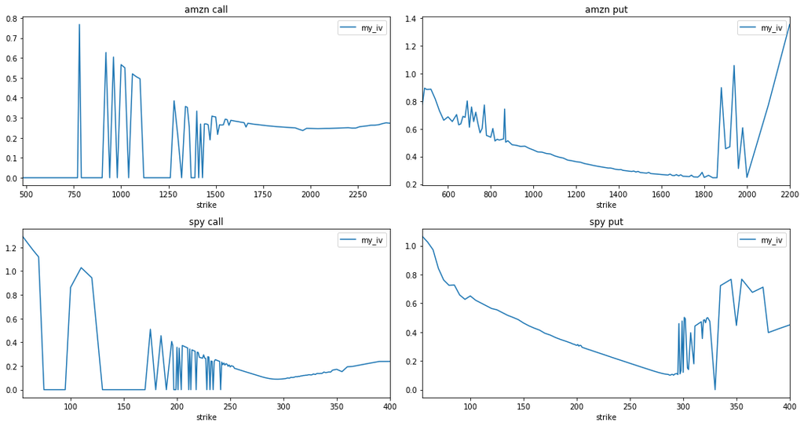

```python
import matplotlib.pyplot as plt
%matplotlib inline
plt.figure(figsize=(15,8))
ax1 = plt.subplot(2,2,1)
amzn_call_concrete_df.plot(x="strike",y="my_iv",ax=ax1,title="amzn call")
ax2 = plt.subplot(2,2,2)
amzn_put_concrete_df.plot(x="strike",y="my_iv",ax=ax2,title="amzn put")
ax3 = plt.subplot(2,2,3)
spy_call_concrete_df.plot(x="strike",y="my_iv",ax=ax3,title="spy call")
ax4 = plt.subplot(2,2,4)
spy_put_concrete_df.plot(x="strike",y="my_iv",ax=ax4,title="spy put")
plt.tight_layout()
```

### Delete the abnormals

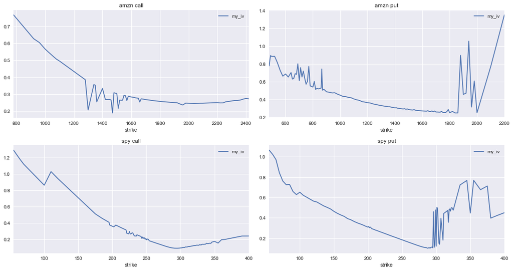

```python
plt.figure(figsize=(15,8))
ax1 = plt.subplot(2,2,1)
amzn_call_concrete_df[amzn_call_concrete_df["my_iv"]>1e-4].plot(x="strike",y="my_iv",ax=ax1,title="amzn call")
ax2 = plt.subplot(2,2,2)
amzn_put_concrete_df[amzn_put_concrete_df["my_iv"]>1e-4].plot(x="strike",y="my_iv",ax=ax2,title="amzn put")
ax3 = plt.subplot(2,2,3)
spy_call_concrete_df[spy_call_concrete_df["my_iv"]>1e-4].plot(x="strike",y="my_iv",ax=ax3,title="spy call")
ax4 = plt.subplot(2,2,4)
spy_put_concrete_df[spy_put_concrete_df["my_iv"]>1e-4].plot(x="strike",y="my_iv",ax=ax4,title="spy put")
plt.tight_layout()
```

### 8. For each option in your table calculate the price of the different type (Call/Put) using the Put-Call parity (please see Section 4 from [2]). Compare the resulting values with the BID/ASK values for the corresponding option if they exist.

Take the spy contract as an example

```python
spy_call_concrete_df.head()
```

|  | contractSymbol | ask | bid | average_price | underlying_price | strike | expiration | time_to_maturity | three_months_rate | impliedVolatility | my_iv |
| --- | --- | --- | --- | --- | --- | --- | --- | --- | --- | --- | --- |
| 0 | SPY180921C00055000 | 222.15 | 221.91 | 222.030 | 276.59 | 55.0 | 1537488000 | 0.257991 | 0.019 | 1.440432 | 1.292575e+00 |
| 1 | SPY180921C00060000 | 217.18 | 216.95 | 217.065 | 276.59 | 60.0 | 1537488000 | 0.257991 | 0.019 | 1.378909 | 1.232866e+00 |
| 2 | SPY180921C00065000 | 212.21 | 211.98 | 212.095 | 276.59 | 65.0 | 1537488000 | 0.257991 | 0.019 | 1.320316 | 1.174029e+00 |
| 3 | SPY180921C00070000 | 207.24 | 207.01 | 207.125 | 276.59 | 70.0 | 1537488000 | 0.257991 | 0.019 | 1.265140 | 1.119632e+00 |
| 4 | SPY180921C00075000 | 191.53 | 191.15 | 191.340 | 276.59 | 75.0 | 1537488000 | 0.257991 | 0.019 | 0.000010 | 1.192093e-07 |

```python
spy_put_concrete_df.head()
```

|  | contractSymbol | ask | bid | average_price | underlying_price | strike | expiration | time_to_maturity | three_months_rate | impliedVolatility | my_iv |
| --- | --- | --- | --- | --- | --- | --- | --- | --- | --- | --- | --- |
| 0 | SPY180921P00055000 | 0.05 | 0.0 | 0.025 | 276.59 | 55.0 | 1537488000 | 0.257991 | 0.019 | 1.054692 | 1.064688 |
| 1 | SPY180921P00060000 | 0.06 | 0.0 | 0.030 | 276.59 | 60.0 | 1537488000 | 0.257991 | 0.019 | 1.011724 | 1.024554 |
| 2 | SPY180921P00065000 | 0.06 | 0.0 | 0.030 | 276.59 | 65.0 | 1537488000 | 0.257991 | 0.019 | 0.960938 | 0.971983 |
| 3 | SPY180921P00070000 | 0.02 | 0.0 | 0.010 | 276.59 | 70.0 | 1537488000 | 0.257991 | 0.019 | 0.828127 | 0.842996 |
| 4 | SPY180921P00075000 | 0.01 | 0.0 | 0.005 | 276.59 | 75.0 | 1537488000 | 0.257991 | 0.019 | 0.750003 | 0.761642 |

```python
put_call_parity_df = pd.DataFrame(columns=["symbol","call","put","my_put","err"])
for symbol,group in spy_call_concrete_df.groupby("contractSymbol"):
    call_price = group["average_price"].values[0]
    S = group["underlying_price"].values[0]
    K = group["strike"].values[0]
    r = r_three_months
    T = group["time_to_maturity"].values[0]
    put_price_using_equilibrium = call_price - S + np.exp(-r*T)*K
    symbol_list = list(symbol)
    symbol_list[9] = 'P'
    put_symbol = "".join(symbol_list)

    try:
        put_price = spy_put_concrete_df[spy_put_concrete_df["contractSymbol"]==put_symbol]["average_price"].values[0]
        err = np.abs(put_price - put_price_using_equilibrium)
    except:
        put_price = float("nan")
        err = float("nan")

    option_series = pd.Series({"symbol":symbol,"call":call_price,"put":put_price,
                               "my_put":put_price_using_equilibrium,"err":err})
    put_call_parity_df = put_call_parity_df.append(option_series,ignore_index=True)
```

```python
put_call_parity_df[51:56]
```

|  | symbol | call | put | my_put | err |
| --- | --- | --- | --- | --- | --- |
| 51 | SPY180921C00235000 | 43.890 | 0.830 | 1.15089 | 0.32089 |
| 52 | SPY180921C00236000 | 43.325 | 0.860 | 1.58100 | 0.72100 |
| 53 | SPY180921C00237000 | 42.360 | 0.895 | 1.61111 | 0.71611 |
| 54 | SPY180921C00238000 | 41.410 | 0.930 | 1.65622 | 0.72622 |
| 55 | SPY180921C00239000 | 40.430 | 0.970 | 1.67133 | 0.70133 |

### 9. Consider the implied volatility values obtained in the previous parts. Create a 2 dimensional plot of implied volatilities versus strike K for the closest to maturity options.

### Take SPY as an example. Firstly, download data of different expirations

```python
one_month_expired = datetime.datetime(2018,7,20)
two_months_expired = datetime.datetime(2018,8,17)
three_months_expired = datetime.datetime(2018,9,21)
```

```python
def get_option_yahoo2(symbol,t_expired):
    unix_expiration = int((t_expired- datetime.datetime(1970,1,1)).total_seconds())
    request = urllib.request.Request("https://query2.finance.yahoo.com/v7/finance/options/{}?date={}".format(symbol,unix_expiration))
    response = urllib.request.urlopen(request)
    option_data = response.read()
    data = json.loads(option_data.decode("utf-8"))
    calls_data = data["optionChain"]["result"][0]["options"][0]["calls"][:]
    puts_data = data["optionChain"]["result"][0]["options"][0]["puts"][:]
    calls_df = pd.DataFrame(calls_data)
    puts_df = pd.DataFrame(puts_data)
    quote_series = pd.Series(data["optionChain"]["result"][0]["quote"])
    return calls_df, puts_df, quote_series
```

```python
calls_df1, puts_df1, quote_series1 = get_option_yahoo2("spy",one_month_expired)
```

```python
calls_df2, puts_df2, quote_series2 = get_option_yahoo2("spy",datetime.datetime(2018,8,17))
```

```python
calls_df2
```

|  | ask | bid | change | contractSize | contractSymbol | currency | expiration | impliedVolatility | inTheMoney | lastPrice | lastTradeDate | openInterest | percentChange | strike | volume |
| --- | --- | --- | --- | --- | --- | --- | --- | --- | --- | --- | --- | --- | --- | --- | --- |
| 0 | 117.49 | 117.29 | 0.0 | REGULAR | SPY180817C00160000 | USD | 1534464000 | 0.727054 | True | 117.28 | 1529358868 | 0 | 0.0 | 160.0 | 256 |
| 1 | 112.52 | 112.32 | 0.0 | REGULAR | SPY180817C00165000 | USD | 1534464000 | 0.695804 | True | 112.31 | 1529358868 | 0 | 0.0 | 165.0 | 112 |
| 2 | 79.73 | 79.52 | 0.0 | REGULAR | SPY180817C00198000 | USD | 1534464000 | 0.501348 | True | 79.12 | 1529358868 | 0 | 0.0 | 198.0 | 4 |
| 3 | 41.16 | 40.97 | 0.0 | REGULAR | SPY180817C00237000 | USD | 1534464000 | 0.300605 | True | 40.86 | 1529358870 | 0 | 0.0 | 237.0 | 4 |

```python
calls_df3, puts_df3, quote_series3 = get_option_yahoo2("spy",three_months_expired)
```

```python
put_df3 = calculate_IV_for_quotes(puts_df3,quote_series3,r_three_months,'p').loc[:,["contractSymbol","ask","bid","average_price","underlying_price","strike","expiration","time_to_maturity","three_months_rate","impliedVolatility","my_iv"]]
put_df2 = calculate_IV_for_quotes(puts_df2,quote_series2,r_three_months,'p').loc[:,["contractSymbol","ask","bid","average_price","underlying_price","strike","expiration","time_to_maturity","three_months_rate","impliedVolatility","my_iv"]]
put_df1 = calculate_IV_for_quotes(puts_df1,quote_series1,r_three_months,'p').loc[:,["contractSymbol","ask","bid","average_price","underlying_price","strike","expiration","time_to_maturity","three_months_rate","impliedVolatility","my_iv"]]

call_df3 = calculate_IV_for_quotes(calls_df3,quote_series3,r_three_months,'c').loc[:,["contractSymbol","ask","bid","average_price","underlying_price","strike","expiration","time_to_maturity","three_months_rate","impliedVolatility","my_iv"]]
call_df2 = calculate_IV_for_quotes(calls_df2,quote_series2,r_three_months,'c').loc[:,["contractSymbol","ask","bid","average_price","underlying_price","strike","expiration","time_to_maturity","three_months_rate","impliedVolatility","my_iv"]]
call_df1 = calculate_IV_for_quotes(calls_df1,quote_series1,r_three_months,'c').loc[:,["contractSymbol","ask","bid","average_price","underlying_price","strike","expiration","time_to_maturity","three_months_rate","impliedVolatility","my_iv"]]
```

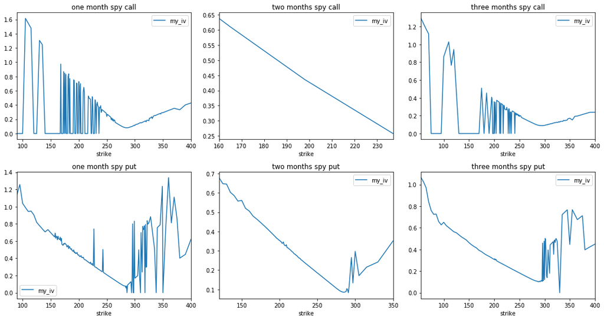

```python
plt.figure(figsize=(15,8))
ax1 = plt.subplot(2,3,1)
call_df1.plot(x="strike",y="my_iv",ax=ax1,title="one month spy call")
ax2 = plt.subplot(2,3,2)
call_df2.plot(x="strike",y="my_iv",ax=ax2,title="two months spy call")
ax3 = plt.subplot(2,3,3)
call_df3.plot(x="strike",y="my_iv",ax=ax3,title="three months spy call")

ax4 = plt.subplot(2,3,4)
put_df1.plot(x="strike",y="my_iv",ax=ax4,title="one month spy put")
ax5 = plt.subplot(2,3,5)
put_df2.plot(x="strike",y="my_iv",ax=ax5,title="two months spy put")
ax6 = plt.subplot(2,3,6)
put_df3.plot(x="strike",y="my_iv",ax=ax6,title="three months spy put")

plt.tight_layout()
```

### Delete abnormal points

```python
call_fix_df1 = call_df1[call_df1["my_iv"]>1e-4]
call_fix_df2 = call_df2[call_df2["my_iv"]>1e-4]
call_fix_df3 = call_df3[call_df3["my_iv"]>1e-4]
put_fix_df1 = put_df1[put_df1["my_iv"]>1e-4]
put_fix_df2 = put_df2[put_df2["my_iv"]>1e-4]
put_fix_df3 = put_df3[put_df3["my_iv"]>1e-4]
```

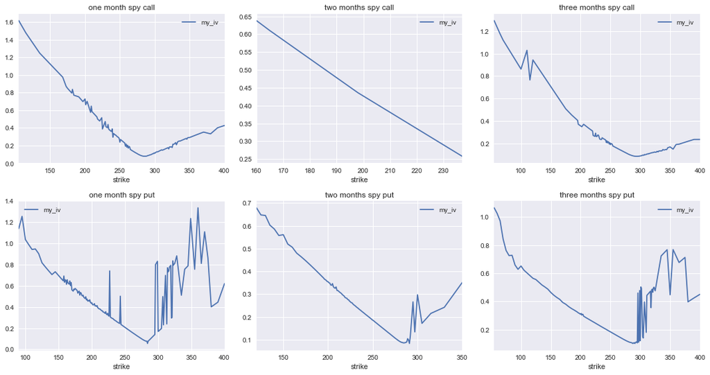

```python
plt.figure(figsize=(15,8))
ax1 = plt.subplot(2,3,1)
call_fix_df1.plot(x="strike",y="my_iv",ax=ax1,title="one month spy call")
ax2 = plt.subplot(2,3,2)
call_fix_df2.plot(x="strike",y="my_iv",ax=ax2,title="two months spy call")
ax3 = plt.subplot(2,3,3)
call_fix_df3.plot(x="strike",y="my_iv",ax=ax3,title="three months spy call")

ax4 = plt.subplot(2,3,4)
put_fix_df1.plot(x="strike",y="my_iv",ax=ax4,title="one month spy put")
ax5 = plt.subplot(2,3,5)
put_fix_df2.plot(x="strike",y="my_iv",ax=ax5,title="two months spy put")
ax6 = plt.subplot(2,3,6)
put_fix_df3.plot(x="strike",y="my_iv",ax=ax6,title="three months spy put")

plt.tight_layout()
```

### Put them into one plot

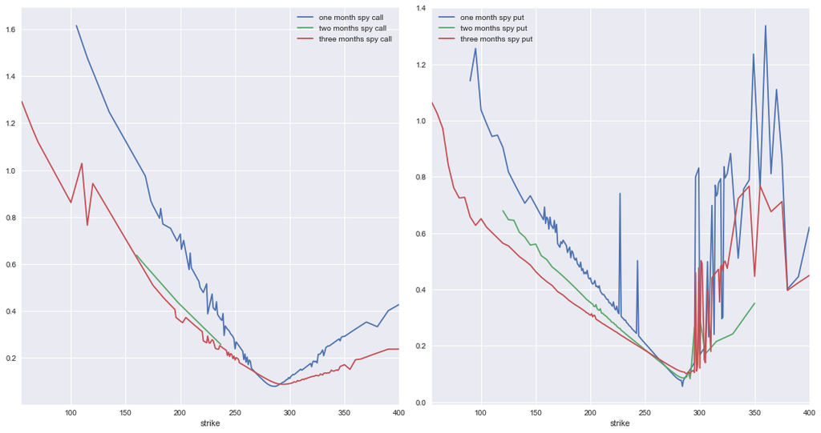

```python
plt.figure(figsize=(15,8))
ax1 = plt.subplot(1,2,1)
call_fix_df1.plot(x="strike",y="my_iv",ax=ax1,label="one month spy call")
call_fix_df2.plot(x="strike",y="my_iv",ax=ax1,label="two months spy call")
call_fix_df3.plot(x="strike",y="my_iv",ax=ax1,label="three months spy call")

ax2 = plt.subplot(1,2,2)
put_fix_df1.plot(x="strike",y="my_iv",ax=ax2,label="one month spy put")
put_fix_df2.plot(x="strike",y="my_iv",ax=ax2,label="two months spy put")
put_fix_df3.plot(x="strike",y="my_iv",ax=ax2,label="three months spy put")

plt.tight_layout()
```

### Conclusion:

The volatility surface become more sharp as options close to the expirations. It illustrate that options away from the moneyness are more valuable or more liquid (no difference in this circumstance) when close to the expirations.

### 10. Greeks: Compare numerical method and theoretical formula results for option Greeks.

```python
def numerical_greeks(S,K,T,r,sigma,option_type):
    epsilon=1e-4
    if(option_type=="c"):
        delta = (BlackSholesPrice(S+epsilon,K,T,r,sigma)[0]-BlackSholesPrice(S-epsilon,K,T,r,sigma)[0])/2/epsilon
        vega = (BlackSholesPrice(S,K,T,r,sigma+epsilon)[0]-BlackSholesPrice(S,K,T,r,sigma-epsilon)[0])/2/epsilon
        gamma = (BlackSholesPrice(S+epsilon,K,T,r,sigma)[0]-2*BlackSholesPrice(S,K,T,r,sigma)[0]+\
             BlackSholesPrice(S-epsilon,K,T,r,sigma)[0])/epsilon**2
    elif(option_type=="p"):
        delta = (BlackSholesPrice(S+epsilon,K,T,r,sigma)[1]-BlackSholesPrice(S-epsilon,K,T,r,sigma)[1])/2/epsilon
        vega = (BlackSholesPrice(S,K,T,r,sigma+epsilon)[1]-BlackSholesPrice(S,K,T,r,sigma-epsilon)[1])/2/epsilon
        gamma = (BlackSholesPrice(S+epsilon,K,T,r,sigma)[1]-2*BlackSholesPrice(S,K,T,r,sigma)[1]+\
             BlackSholesPrice(S-epsilon,K,T,r,sigma)[1])/epsilon**2
    return delta,vega,gamma
```

```python
def theoretical_greeks(S,K,T,r,sigma,option_type):
    N = lambda x: sp.stats.norm.cdf(x)
    d1 = (np.log(S/K) + r*T + sigma**2*T/2)/sigma/np.sqrt(T)
    d2 = d1 - sigma * np.sqrt(T)

    if(option_type=="c"):
        delta = N(d1)
        gamma = 1/(S*sigma*np.sqrt(T*2*np.pi))*np.exp(-d1**2/2)
        vega = S*np.sqrt(T)*np.exp(-.5*d1**2)/np.sqrt(2*np.pi)
    elif(option_type=="p"):
        delta = (N(d1)-1)
        gamma = 1/(S*sigma*np.sqrt(T*2*np.pi))*np.exp(-d1**2/2)
        vega = S*np.sqrt(T)*np.exp(-.5*d1**2)/np.sqrt(2*np.pi)
    return delta,vega,gamma
```

```python
print("numerical greeks for calls: (delta,vega,gamma) {}".format(numerical_greeks(100,100,1,0.05,0.3,'c')))
print("theoretical greeks for calls: (delta,vega,gamma) {}".format(theoretical_greeks(100,100,1,0.05,0.3,'c')))
```

```
numerical greeks for calls: (delta,vega,gamma) (0.6242517278920445, 37.94329323731915, 0.012649792324737064)
theoretical greeks for calls: (delta,vega,gamma) (0.6242517279060125, 37.94329331169454, 0.012647764437231512)
```

```python
print("numerical greeks for puts: (delta,vega,gamma) {}".format(numerical_greeks(100,100,1,0.05,0.3,'p')))
print("theoretical greeks for puts: (delta,vega,gamma) {}".format(theoretical_greeks(100,100,1,0.05,0.3,'p')))
```

```
numerical greeks for puts: (delta,vega,gamma) (-0.3757482721056249, 37.94329323739021, 0.012651923952944344)
theoretical greeks for puts: (delta,vega,gamma) (-0.37574827209398753, 37.94329331169454, 0.012647764437231512)
```

### 11. Next we will use the second dataset DATA2. For each strike price in the data use the Stock price for the same day, the implied volatility you calculated from DATA1 and the current short-term interest rate (corresponding to the day on which DATA2 was gathered). Use the Black-Scholes formula, to calculate the option price.

### Read DATA2

```python
spy_call_d2 = pd.read_csv("spy_call_{}.csv".format(date2_str))
spy_put_d2 = pd.read_csv("spy_put_{}.csv".format(date2_str))
spy_quote_d2 = pd.Series.from_csv("spy_quote_{}.csv".format(date2_str))
amzn_call_d2 = pd.read_csv("amzn_call_{}.csv".format(date2_str))
amzn_put_d2 = pd.read_csv("amzn_put_{}.csv".format(date2_str))
amzn_quote_d2 = pd.Series.from_csv("amzn_quote_{}.csv".format(date2_str))
```

```python
spy_call_d2.head()
```

|  | Unnamed: 0 | ask | bid | change | contractSize | contractSymbol | currency | expiration | impliedVolatility | inTheMoney | lastPrice | lastTradeDate | openInterest | percentChange | strike | volume |
| --- | --- | --- | --- | --- | --- | --- | --- | --- | --- | --- | --- | --- | --- | --- | --- | --- |
| 0 | 0 | 222.15 | 221.91 | 0.149994 | REGULAR | SPY180921C00055000 | USD | 1537488000 | 1.780763 | True | 221.65 | 1529342657 | 21 | 0.067717 | 55.0 | 831 |
| 1 | 1 | 217.18 | 216.95 | -0.080002 | REGULAR | SPY180921C00060000 | USD | 1537488000 | 1.692873 | True | 216.69 | 1529342808 | 153 | -0.036906 | 60.0 | 640 |
| 2 | 2 | 212.21 | 211.98 | 0.220001 | REGULAR | SPY180921C00065000 | USD | 1537488000 | 1.611818 | True | 211.69 | 1529342808 | 10 | 0.104034 | 65.0 | 285 |
| 3 | 3 | 207.24 | 207.01 | 8.220001 | REGULAR | SPY180921C00070000 | USD | 1537488000 | 1.536868 | True | 205.75 | 1529331416 | 0 | 4.161394 | 70.0 | 10 |
| 4 | 4 | 191.53 | 191.15 | 0.000000 | REGULAR | SPY180921C00075000 | USD | 1537488000 | 0.000010 | True | 189.56 | 1525492482 | 99 | 0.000000 | 75.0 | 99 |

### Calculate the implied volatility of DATA2

```python
spy_call_df2 = calculate_IV_for_quotes(spy_call_d2,spy_quote_d2,r_three_months,'c')
amzn_call_df2 = calculate_IV_for_quotes(amzn_call_d2,amzn_quote_d2,r_three_months,'c')
spy_put_df2 = calculate_IV_for_quotes(spy_put_d2,spy_quote_d2,r_three_months,'p')
amzn_put_df2 = calculate_IV_for_quotes(amzn_put_d2,amzn_quote_d2,r_three_months,'p')
```

### Output a more concrete form

```python
def concrete_option_df(df):
    return df.loc[:,["contractSymbol","ask","bid","average_price","underlying_price","strike","expiration","time_to_maturity","three_months_rate","impliedVolatility","my_iv"]]
```

```python
spy_call_concrete_df2 = concrete_option_df(spy_call_df2)
spy_put__concrete_df2 = concrete_option_df(spy_put_df2)
amzn_call_concrete_df2 = concrete_option_df(amzn_call_df2)
amzn_put_concrete_df2 = concrete_option_df(amzn_put_df2)
```

### DATA1

```python
# spy_call_concrete_df
# spy_put_concrete_df
# amzn_call_concrete_df
# amzn_put_concrete_df
```

### Comparison

For the same contract, the implied volatilities of two consecutive days are different.

```python
spy_call_concrete_df.iloc[50:55]
```

|  | contractSymbol | ask | bid | average_price | underlying_price | strike | expiration | time_to_maturity | three_months_rate | impliedVolatility | my_iv |
| --- | --- | --- | --- | --- | --- | --- | --- | --- | --- | --- | --- |
| 50 | SPY180921C00234000 | 32.44 | 32.16 | 32.300 | 276.59 | 234.0 | 1537488000 | 0.257991 | 0.019 | 0.000010 | 1.192093e-07 |
| 51 | SPY180921C00235000 | 43.99 | 43.79 | 43.890 | 276.59 | 235.0 | 1537488000 | 0.257991 | 0.019 | 0.281990 | 2.378062e-01 |
| 52 | SPY180921C00236000 | 43.48 | 43.17 | 43.325 | 276.59 | 236.0 | 1537488000 | 0.257991 | 0.019 | 0.293647 | 2.532150e-01 |
| 53 | SPY180921C00237000 | 42.52 | 42.20 | 42.360 | 276.59 | 237.0 | 1537488000 | 0.257991 | 0.019 | 0.289497 | 2.495822e-01 |
| 54 | SPY180921C00238000 | 41.56 | 41.26 | 41.410 | 276.59 | 238.0 | 1537488000 | 0.257991 | 0.019 | 0.285285 | 2.465359e-01 |

```python
spy_call_concrete_df2.iloc[50:55]
```

|  | contractSymbol | ask | bid | average_price | underlying_price | strike | expiration | time_to_maturity | three_months_rate | impliedVolatility | my_iv |
| --- | --- | --- | --- | --- | --- | --- | --- | --- | --- | --- | --- |
| 50 | SPY180921C00233000 | 45.88 | 45.58 | 45.730 | 275.45 | 233.0 | 1537488000 | 0.2554 | 0.019 | 0.324836 | 2.888068e-01 |
| 51 | SPY180921C00234000 | 32.44 | 32.16 | 32.300 | 275.45 | 234.0 | 1537488000 | 0.2554 | 0.019 | 0.000010 | 1.192093e-07 |
| 52 | SPY180921C00235000 | 43.99 | 43.79 | 43.890 | 275.45 | 235.0 | 1537488000 | 0.2554 | 0.019 | 0.316840 | 2.839946e-01 |
| 53 | SPY180921C00236000 | 43.48 | 43.17 | 43.325 | 275.45 | 236.0 | 1537488000 | 0.2554 | 0.019 | 0.325996 | 2.941004e-01 |
| 54 | SPY180921C00237000 | 42.52 | 42.20 | 42.360 | 275.45 | 237.0 | 1537488000 | 0.2554 | 0.019 | 0.321235 | 2.896343e-01 |

### Use implied volatilities in DATA1 to predict option price in DATA2

Here, we take spy call option as an example. Note that the 3 months rates are the same according to the website.

```python
def predict_consecutive_day_price(option_df,option_df2,r,option_type):
    my_price = []
    option_df2 = option_df2.copy()
    for symbol,group in option_df2.groupby("contractSymbol"):
        S = group["underlying_price"].values[0]
        K = group["strike"].values[0]
        T = group["time_to_maturity"].values[0]
        try:
            sigma = option_df[option_df["contractSymbol"]==symbol]["my_iv"].values[0]
            option_price = BlackSholesPrice(S,K,T,r,sigma)

            if(option_type=="c"):
                my_price.append(option_price[0])
            elif(option_type=="p"):
                my_price.append(option_price[1])
        except:
            # the contract cannot be found in the former day. Denote the prediction as nan
            my_price.append(float("nan"))
    option_df2["my_price"] = my_price
    return option_df2
```

```python
spy_call_concrete_df2 = predict_consecutive_day_price(spy_call_concrete_df,spy_call_concrete_df2,r_three_months,"c")
```

```python
spy_call_concrete_df2.loc[:,["contractSymbol","my_price","average_price"]].loc[50:55]
```

|  | contractSymbol | my_price | average_price |
| --- | --- | --- | --- |
| 50 | SPY180921C00233000 | 44.633871 | 45.730 |
| 51 | SPY180921C00234000 | 42.582758 | 32.300 |
| 52 | SPY180921C00235000 | 42.801766 | 43.890 |
| 53 | SPY180921C00236000 | 42.250984 | 43.325 |
| 54 | SPY180921C00237000 | 41.288843 | 42.360 |
| 55 | SPY180921C00238000 | 40.342219 | 41.410 |

### Conclusion:

It seems that the prediction is similar to the true value. From the table above, the price predictions are sometimes higher and sometimes lower.

## Part 3. Numerical Integration of real-valued functions.

### 1. Implement the trapezoidal and the Simpson's quadrature rules to numerically approximate the indefinite integral as follows.

$$f(x) = \begin{cases} \frac{sin(x)}{x} &x \neq 0\\ 1 & x=0 \end{cases} $$

```python
def Simpson(f, a, b, n=500):
    """
    Return the approximation of the integral of f
    from a to b using Simpson's rule with n intervals.
    """
    n=int(n)
    if a > b:
        print('Error: a={} > b={}'.format(a, b))
        return None

    # Check that n is even
    if n % 2 != 0:
#         print('Error: n={} is not an even integer!'.format(n))
        n = n+1  # make n even

    h = (b - a)/float(n)
    sum1 = 0
#     print(n/2+1)
    for i in range(1, int(n/2) + 1):
        sum1 += f(a + (2*i-1)*h)

    sum2 = 0
    for i in range(1, int(n/2)):
        sum2 += f(a + 2*i*h)

    integral = (b-a)/(3*n)*(f(a) + f(b) + 4*sum1 + 2*sum2)
    return integral
```

```python
def Trapezoid(f, a, b, n=500):
    """
    Return the approximation of the integral of f
    from a to b using Simpson's rule with n intervals.
    """
    n=int(n)
    if a > b:
        print('Error: a={} > b={}'.format(a, b))
        return None
    x_array = np.linspace(a,b,n+1)
    col = np.ones(n+1)
    col[0] = 1/2
    col[-1] = 1/2
    dx = (b-a)/n
    return np.dot(f(x_array)*dx,col)
```

```python
np.asanyarray?
```

```python
a = np.asanyarray([1,2,3,0,2])
np.where(a==0,100,a)
```

```
array([  1,   2,   3, 100,   2])
```

```python
def my_sinc(x):
    a = np.asanyarray(x)
    y = np.where(a==0,1e-6,a)
    return np.sin(y)/y
```

```python
Simpson(my_sinc,-1e6,1e6,n=5000000)
```

```
3.141590779814681
```

```python
Trapezoid(my_sinc,-1e6,1e6,n=5000000)
```

```
3.1415908051331125
```

### 2. Compute the truncation error for the numerical algorithms

### Behavior truncation error when a increase from 1e2 to 1e5, N from 1e2 to 1e5

```python
a_list = [1e2,1e3,1e4,1e5]
N_list = [1e2,1e3,1e4,1e5]
simpson_error_matrix = np.zeros((4,4))
trapezoid_error_matrix = np.zeros((4,4))
for i,a in enumerate(a_list):
    for j,N in enumerate(N_list):
        simpson_error_matrix[i,j] = Simpson(my_sinc,-a,a,N)-np.pi
        trapezoid_error_matrix[i,j] = Trapezoid(my_sinc,-a,a,N)-np.pi
```

```python
log_simpson_error = np.log10(np.abs(simpson_error_matrix))
log_trapezoid_error = np.log10(np.abs(trapezoid_error_matrix))
```

```python
log_simpson_error_df = pd.DataFrame(log_simpson_error,columns=["1e2","1e3","1e4","1e5"],index=["1e2","1e3","1e4","1e5"])
log_simpson_error_df
```

|  | 1e2 | 1e3 | 1e4 | 1e5 |
| --- | --- | --- | --- | --- |
| 1e2 | -1.699182 | -1.765942 | -1.765946 | -1.765946 |
| 1e3 | 1.098510 | -2.883876 | -2.948300 | -2.948304 |
| 1e4 | 2.106266 | 1.099326 | -3.655341 | -3.720244 |
| 1e5 | 3.124523 | 2.106376 | 1.099222 | -4.634330 |

```python
log_trapezoid_error_df = pd.DataFrame(log_trapezoid_error,columns=["1e2","1e3","1e4","1e5"],index=["1e2","1e3","1e4","1e5"])
log_trapezoid_error_df
```

|  | 1e2 | 1e3 | 1e4 | 1e5 |
| --- | --- | --- | --- | --- |
| 1e2 | -1.961472 | -1.767414 | -1.765960 | -1.765946 |
| 1e3 | 1.274889 | -3.139942 | -2.949750 | -2.948318 |
| 1e4 | 2.289470 | 1.275369 | -3.912634 | -3.721699 |
| 1e5 | 3.300610 | 2.289534 | 1.275308 | -4.891650 |

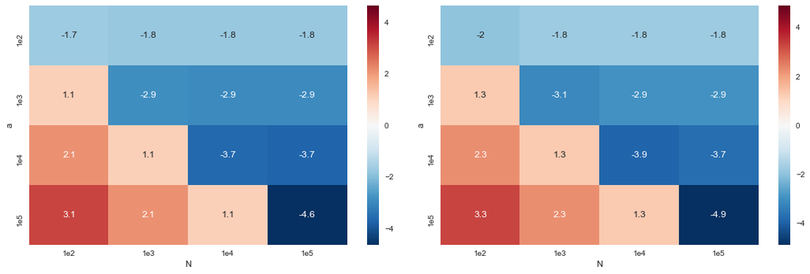

```python
import seaborn as sns
plt.figure(figsize=(15,5))
plt.subplot(1,2,1)

sns.heatmap(log_simpson_error_df,annot=True)
plt.xlabel("N")
plt.ylabel("a")

plt.subplot(1,2,2)

sns.heatmap(log_trapezoid_error_df,annot=True)
plt.xlabel("N")
plt.ylabel("a")

plt.tight_layout()
```

### 3. In this part, we write a function to decide the integration steps. The algorithm is conducted by an iterative process. In each iteration, we check the absolute error of the recent result and the result one step before. If the absolute error is smaller than some tolerance value, the algorithm stops.

```python
def find_convergence(func, n_list, tol):
    for i,n in enumerate(n_list):
        if(i!=0 and np.abs(func(n)-old)<tol):
            break
        old = func(n)
    if(old != func(n_list[-1])):
        return n,func(n)
    else:
        print("please enlarge your steps")
```

### Take $a=10^4$ as an example. We check both the simpson rule and the trapzoid rule for sinc function

```python
simpson_n,simpson_value = find_convergence(lambda n: Simpson(my_sinc,-1e4,1e4,n),np.linspace(5e3,1e5,50),1e-4)
int(simpson_n)
```

```
10816
```

```python
trapezoid_n,trapezoid_value = find_convergence(lambda n: Trapezoid(my_sinc,-1e4,1e4,n),np.linspace(5e3,1e5,50),1e-4)
int(trapezoid_n)
```

```
8877
```

### 4.Use the trapezoidal rule and Simpson's rule to approximate $\int_0^2 g(x)dx$. Use a tolerance level of $\epsilon=10^{-4}$.

$$g(x) = 1 + e^{-x^2}cos(8 x ^{3/2})$$

```python
g = lambda x: 1+np.exp(-x**2)*np.cos(8*x**(3/2))
```

```python
simpson_n,simpson_value = find_convergence(lambda n: Simpson(g,0,2,n),np.linspace(10,100,50),1e-4)
print("number of segments: {}, integral value: {}".format(int(simpson_n),simpson_value))
```

```
number of segments: 17, integral value: 2.1232800162390055
```

```python
trapezoid_n,trapezoid_value = find_convergence(lambda n: Trapezoid(g,0,2,n),np.linspace(10,100,50),1e-4)
print("number of segments: {}, integral value: {}".format(int(trapezoid_n),trapezoid_value))
```

```
number of segments: 15, integral value: 2.1235732649472747
```